# ARMA/ARIMA/SARIMA

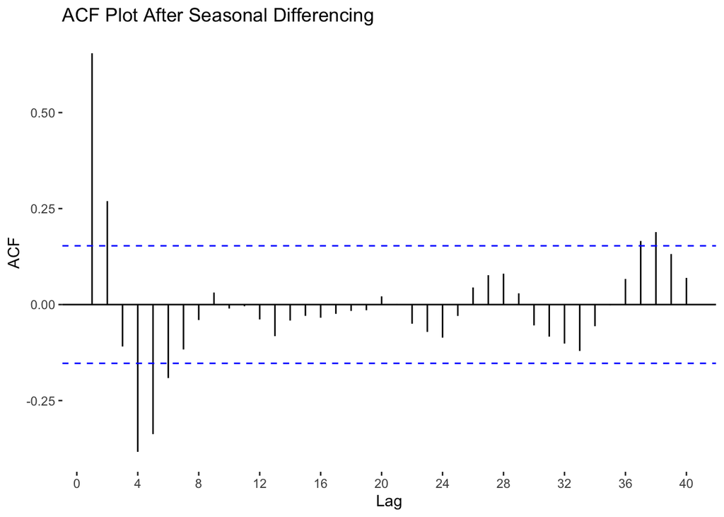

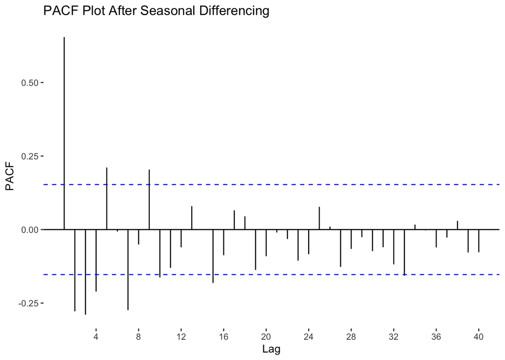

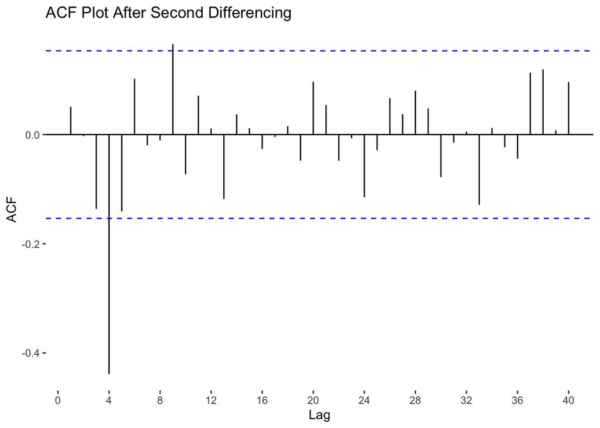

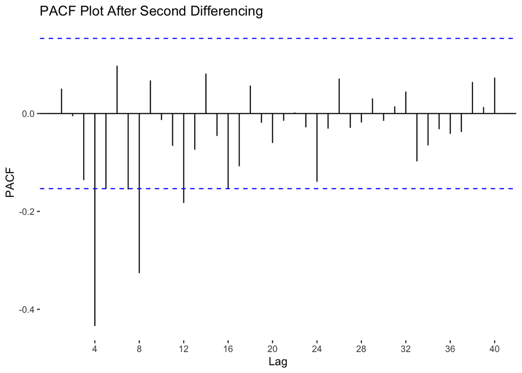

### Model Fitting

After differencing `6 Month T-Bill Yield`, ACF and PACF show significance at multiple lags. This suggests ARIMA parameters `p = [0,1,2,3]`, `P = [2]`, `d = [1]`, `[D = 1]`, `q = [0,1,2,3], Q = [1]`. I’ll test these for the lowest `AIC`, `BIC`, and `AICc`, and cross-check with `auto.arima` to forecasting.

```
Minimum AIC: 2, 1, 2, 2, 1, 1, -0.473054691655761, 24.2769469147983, 0.462010243409175
```

```
Minimum BIC: 1, 1, 1, 2, 1, 1, 5.03140449969021, 23.5939057045308, 5.56986603815175
```

```
Minimum AICc: 2, 1, 2, 2, 1, 1, -0.473054691655761, 24.2769469147983, 0.462010243409175
```

**auto.arima**

```
Series: ts
ARIMA(0,1,0)(2,0,0)[4]

Coefficients:
         sar1     sar2
      -0.2138  -0.2045
s.e.   0.0909   0.0933

sigma^2 = 0.05475:  log likelihood = 6.38
AIC=-6.75   AICc=-6.61   BIC=2.6
```

### Model Diagnostics

In the model fitting analysis, three prominent models emerged: `SARIMA(0,1,0)(2,0,0)[4]`, `SARIMA(2,1,2)(2,1,1)[4]` and `SARIMA(1,1,1)(2,1,1)[4]`. The diagnostic comparison for these models focuses on evaluating key summary statistics, including the presence of a white noise pattern in the residuals, p-values, and critical model selection criteria like AIC, AICc, and BIC.

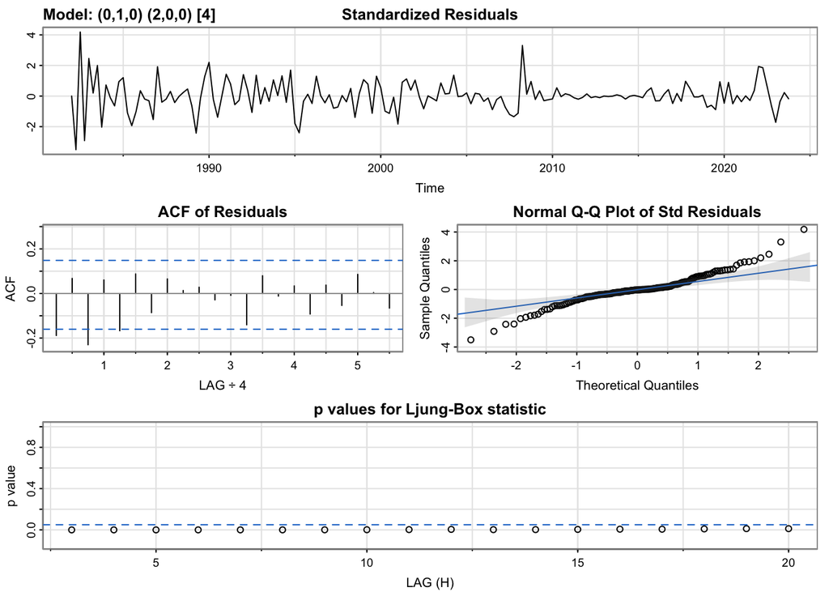

```
 [1] "Call:"
 [2] "arima(x = xdata, order = c(p, d, q), seasonal = list(order = c(P, D, Q), period = S), "
 [3] "    xreg = constant, transform.pars = trans, fixed = fixed, optim.control = list(trace = trc, "
 [4] "        REPORT = 1, reltol = tol))"
 [5] ""
 [6] "Coefficients:"
 [7] "         sar1     sar2  constant"
 [8] "      -0.2142  -0.2046    0.0022"
 [9] "s.e.   0.0910   0.0933    0.0128"
[10] ""
[11] "sigma^2 estimated as 0.05408:  log likelihood = 6.39,  aic = -4.78"
[12] ""
[13] "$degrees_of_freedom"
[14] "[1] 164"
[15] ""
[16] "$ttable"
[17] "         Estimate     SE t.value p.value"
[18] "sar1      -0.2142 0.0910 -2.3553  0.0197"
[19] "sar2      -0.2046 0.0933 -2.1921  0.0298"
[20] "constant   0.0022 0.0128  0.1753  0.8611"
[21] ""
[22] "$AIC"
[23] "[1] -0.02864336"
[24] ""
[25] "$AICc"
[26] "[1] -0.02776168"
[27] ""
[28] "$BIC"
[29] "[1] 0.04603913"
[30] ""
```

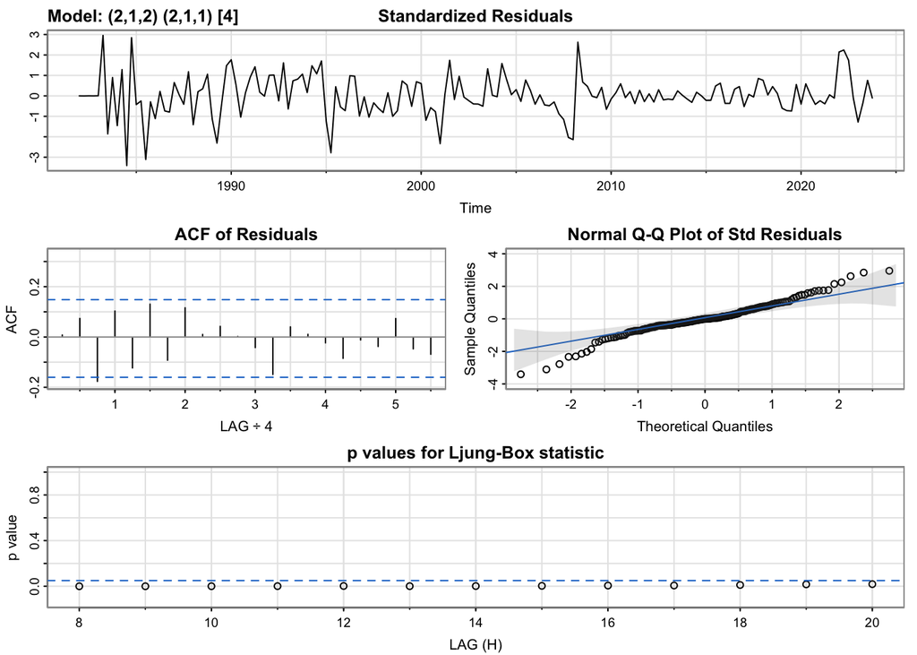

```
 [1] "Call:"
 [2] "arima(x = xdata, order = c(p, d, q), seasonal = list(order = c(P, D, Q), period = S), "
 [3] "    include.mean = !no.constant, transform.pars = trans, fixed = fixed, optim.control = list(trace = trc, "
 [4] "        REPORT = 1, reltol = tol))"
 [5] ""
 [6] "Coefficients:"
 [7] "          ar1     ar2      ma1      ma2     sar1     sar2     sma1"
 [8] "      -0.1820  0.8030  -0.1146  -0.8854  -0.2283  -0.2178  -0.9541"
 [9] "s.e.   0.0611  0.0563   0.0685   0.0667   0.0991   0.0979   0.0638"
[10] ""
[11] "sigma^2 estimated as 0.04746:  log likelihood = 8.24,  aic = -0.47"
[12] ""
[13] "$degrees_of_freedom"
[14] "[1] 156"
[15] ""
```

[output cut: 19 more lines]

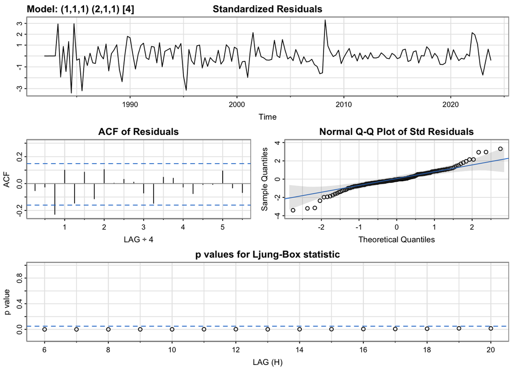

```
 [1] "Call:"
 [2] "arima(x = xdata, order = c(p, d, q), seasonal = list(order = c(P, D, Q), period = S), "
 [3] "    include.mean = !no.constant, transform.pars = trans, fixed = fixed, optim.control = list(trace = trc, "
 [4] "        REPORT = 1, reltol = tol))"
 [5] ""
 [6] "Coefficients:"
 [7] "          ar1     ma1     sar1     sar2     sma1"
 [8] "      -0.9902  0.8509  -0.2971  -0.2563  -0.9561"
 [9] "s.e.   0.0226  0.0712   0.0916   0.0946   0.0585"
[10] ""
[11] "sigma^2 estimated as 0.05234:  log likelihood = 3.48,  aic = 5.03"
[12] ""
[13] "$degrees_of_freedom"
[14] "[1] 158"
[15] ""
```

[output cut: 17 more lines]

Equation for `SARIMA(2,1,2)(2,1,1)[4]`:

$$(1 - \phi_1 B - \phi_2 B^2)(1 - B)(1 - \Phi_1 B^s - \Phi_2 B^{2s})(1 - B^s)X_t = (1 + \theta_1 B + \theta_2 B^2)(1 + \Theta_1 B^s)W_t$$

```
Series: ts
ARIMA(2,1,2)(2,1,1)[4]

Coefficients:
          ar1     ar2      ma1      ma2     sar1     sar2     sma1
      -0.1820  0.8030  -0.1146  -0.8854  -0.2283  -0.2178  -0.9541
s.e.   0.0611  0.0563   0.0685   0.0667   0.0991   0.0979   0.0638

sigma^2 = 0.04959:  log likelihood = 8.24
AIC=-0.47   AICc=0.46   BIC=24.28

Training set error measures:
                      ME      RMSE       MAE      MPE     MAPE      MASE
Training set 0.004070017 0.2145945 0.1528131 104.5816 243.6773 0.5254351
                  ACF1
Training set 0.0078855
```